# Week 2

# Central limit theorem

Normal approximation –> needs only mu (average) and sigma (standard deviation) to define distribution + integral can be used to estimate proportion of all values within an interval + QQ plots compute for each percentile the number of data that is expected to be below that data and plot explected vs. observed + Standard units + If data is aprox normal -> can be converted into standard units by substracting mean and dividing by SD –> normal distribution with mean = 0 and SD = 1 –> Z score (standard normal distribution) Z score == amount of SDs far away from mean

## Normal distribution exercise

### take samples and assess distribution

[figure not shown]

```r
# make averages5
set.seed(1)
n <- 1000
averages5 <- vector("numeric",n)

for(i in 1:n){
  X <- sample(femaleMiceControl,5)
  averages5[i] <- mean(X)
}

# make averages50
set.seed(1)
n <- 1000
averages50 <- vector("numeric",n)
for(i in 1:n){
  X <- sample(femaleMiceControl,50)
  averages50[i] <- mean(X)
}

par(mfrow=c(1,2))
hist(averages5)
hist(averages50)
```

### Proportion of averages between 23 and 25

```r
avFilt<-averages50>=23 & averages50<=25
mean(avFilt)
```

```
[1] 0.982
```

### Generalised: find poroportion of observations between 23-25 with mu=23.9 and sigma =0.43 (like the data above…)

- use pnorm function
  - pnorm(x, mu, sigma)
  - x= cutof

```r
pnorm(25,23.9,0.43)-pnorm(23,23.9,0.43)
```

```
[1] 0.9765648
```

## Populations, parameteres and sample estimates

- if only samples from populations can be taken (not entire population) –> statistical inference
  - take random measurements from populations

Population average –> mu of different groups are searched and compared

Sample averages are random variables

## Populations exercise

### get data

```r
micePheno<-read_csv("https://raw.githubusercontent.com/genomicsclass/dagdata/master/inst/extdata/mice_pheno.csv")%>%na.omit()
glimpse(micePheno)
```

```
Rows: 841
Columns: 3
$ Sex        <chr> "F", "F", "F", "F", "...
$ Diet       <chr> "hf", "hf", "hf", "hf...
$ Bodyweight <dbl> 31.94, 32.48, 22.82, ...
```

```r
head(micePheno)
```

| Sex | Diet | Bodyweight |
| --- | --- | --- |
| F | hf | 31.94 |
| F | hf | 32.48 |
| F | hf | 22.82 |
| F | hf | 19.92 |
| F | hf | 32.22 |
| F | hf | 27.50 |

```r
micePheno%>%filter(Sex=="M",Diet=="chow")%>%select(Bodyweight)%>%
  unlist()->maleChow

micePheno%>%filter(Sex=="M",Diet=="hf")%>%select(Bodyweight)%>%
  unlist()->maleHf
```

### mean and population SD

```r
library(rafalib)
mean(maleChow)
```

```
[1] 30.96381
```

```r
popsd(maleChow)
```

```
[1] 4.420501
```

```r
mean(maleHf)
```

```
[1] 34.84793
```

```r
popsd(maleHf)
```

```
[1] 5.574609
```

### sample means

```r
set.seed(1)
mean(sample(maleChow,25))->maleChowSampleMean
set.seed(1)
mean(sample(maleHf,25))->maleHfSampleMean
```

### abs difference between differences in sample and population means

```r
mean(maleChow) - mean(maleHf) ->malePopDif
maleChowSampleMean - maleHfSampleMean -> maleSampleDif

abs(malePopDif - maleSampleDif)
```

```
[1] 1.399884
```

```r
micePheno%>%filter(Sex=="F",Diet=="chow")%>%select(Bodyweight)%>%
  unlist()->femaleChow

micePheno%>%filter(Sex=="F",Diet=="hf")%>%select(Bodyweight)%>%
  unlist()->femaleHf
```

### abs difference between differences in sample and population means

```r
set.seed(2)
mean(sample(femaleChow,25))->femaleChowSampleMean
set.seed(2)
mean(sample(femaleHf,25))->femaleHfSampleMean

mean(femaleChow) - mean(femaleHf) ->femalePopDif
femaleChowSampleMean - femaleHfSampleMean -> femaleSampleDif

abs(femalePopDif - femaleSampleDif)
```

```
[1] 0.3647172
```

Central limit theorem –> sample average follows normal distribution with mean population average and $sigma = sigmaX/sqrt(N)$ + SigmaX –> population standard deviation (typical deviation from mean) + Sample average –> random variable + repeated samples –> sample means would follow the aforementioned normal distribution $N(mu_x,\frac{sigma_x}{\sqrt{N}})$

How to use this in practice? Differences betwen two sample means:

$N(0,1) = \frac{Y - X}{\sqrt{{sigma_x^2}/{N} + sigma_y^2/N}}$ if H0 == TRUE –> with increasing N, SD of final distribution decreases, histogram gets “narrower”. + Problem in real life: Population SD is not known –> t.test is needed

## Exercise CLt

```r
pnorm(3) - pnorm(-3)
```

```
[1] 0.9973002
```

### proportin of male control mice within 1Sd from average weight

```r
maleChowMean<-mean(maleChow)
maleChowSD<-popsd(maleChow)

1- (mean(maleChow >=maleChowMean+maleChowSD) + mean(maleChow <=maleChowMean-maleChowSD))
```

```
[1] 0.6950673
```

```r
# W/in 2sd
1- (mean(maleChow >=maleChowMean+2*maleChowSD) + mean(maleChow <=maleChowMean-2*maleChowSD))
```

```
[1] 0.9461883
```

```r
# W/in 3sd
1- (mean(maleChow >=maleChowMean+3*maleChowSD) + mean(maleChow <=maleChowMean-3*maleChowSD))
```

```
[1] 0.9910314
```

### test CLT

```r
set.seed(1)
avgs<-replicate(10000, mean(sample(maleChow,25)))
mypar(1,2)
hist(avgs)
qqnorm(avgs)
```

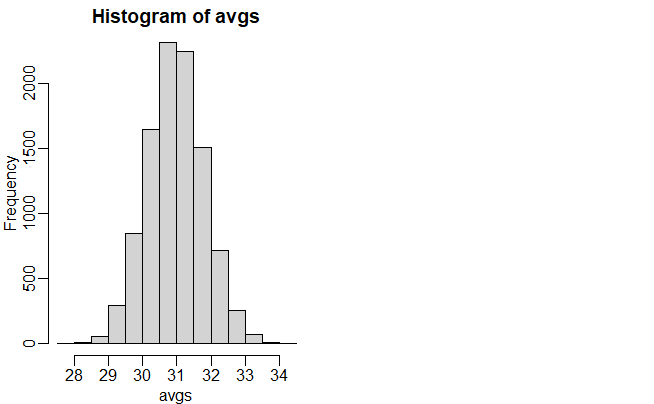

```r
qqline(avgs)
```

```r
mean(avgs)
```

```
[1] 30.96856
```

```r
popsd(avgs)
```

```
[1] 0.827082
```

# t.test

t statisticsc: $\frac{observed diff}{standard error}$

## t.test exercise

### Simluate clt with rolled dice

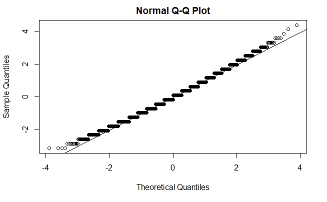

### run previous simulations with different p’s and n’S

```r
p<-0.5
n<-30

replicate(10000, dice(n,p))->out

# z distribution should be N(0,1)
qqnorm(out)
qqline(out)

mean(out)
sd(out)
```

### Mouse example

```r
sd(x)
```

```
[1] 3.022541
```

mean(x) follows normal distribution $N(µ_x,\frac{sigma_x}{\sqrt{n}}$

Z distribution: $Z=\sqrt{n}*\frac{\bar{x}-µ_x}{\sigma_x}$ –> $Z=N(0,1)$

# Use CLT to apprximate p for popMean of by more thatn 2 grams for mean(x)

mean(x) follows sd with N(µ_x, sd/sqrt(12))

```r
(1-pnorm(z))*2
```

```
[1] 0.02189533
```

## Null hypotheses

No effect –> $µ_x=µ_y$ Use the CLT to approx $\bar{X}=N(µ_x,\frac{\sigma_x}{\sqrt{m}}$ and $\bar{Y}$ accordingly. If Null hypthesis is true: $mean(\bar{X}-\bar{Y})=0$ and sd of this statistics is $SE(\bar{X} -\bar{Y})= \sqrt{\frac{\sigma_y^2}{12}+\frac{\sigma_x^2}{12}}$

```r
SE
```

```
[1] 1.469867
```

# compute t.statistic

$t=\frac{diff}{SE}$

```r
t.test(x,y)
```

```
    Welch Two Sample t-test

data:  x and y
t = -2.0552, df = 20.236, p-value = 0.053
alternative hypothesis: true difference in means is not equal to 0
95 percent confidence interval:
 -6.08463229  0.04296563
sample estimates:
mean of x mean of y
 23.81333  26.83417
```

## more clt and tstats

2.055174 ### pvalue based on t-stats T distribution accounts for variability introduced by estimation –> larger values more probably under null distribution (fatter tails)

```r
t.test(x,y)
```

```
    Welch Two Sample t-test

data:  x and y
t = -2.0552, df = 20.236, p-value = 0.053
alternative hypothesis: true difference in means is not equal to 0
95 percent confidence interval:
 -6.08463229  0.04296563
sample estimates:
mean of x mean of y
 23.81333  26.83417
```